# Sberbank Springboard Capstone project

Dylan Distasio

May 22, 2017

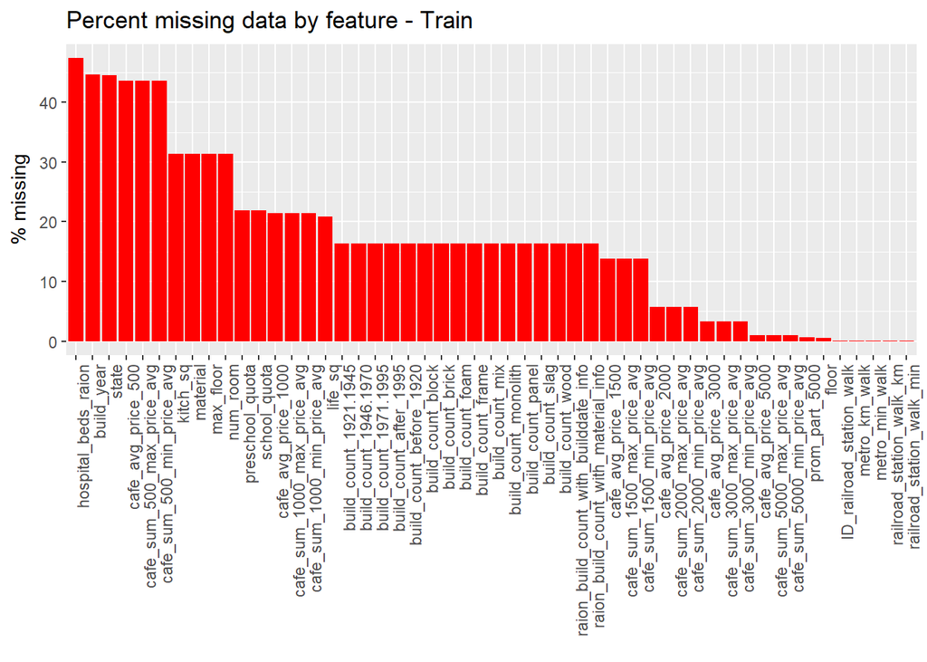

```r
# Missing values in training dataset
miss_pct <- map_dbl(train, function(x) { round((sum(is.na(x)) / length(x)) * 100, 1) })

miss_pct <- miss_pct[miss_pct > 0]

data.frame(miss=miss_pct, var=names(miss_pct), row.names=NULL) %>%
    ggplot(aes(x=reorder(var, -miss), y=miss)) +
    geom_bar(stat='identity', fill='red') +
    labs(x='', y='% missing', title='Percent missing data by feature - Train') +
    theme(axis.text.x=element_text(angle=90, hjust=1))
```

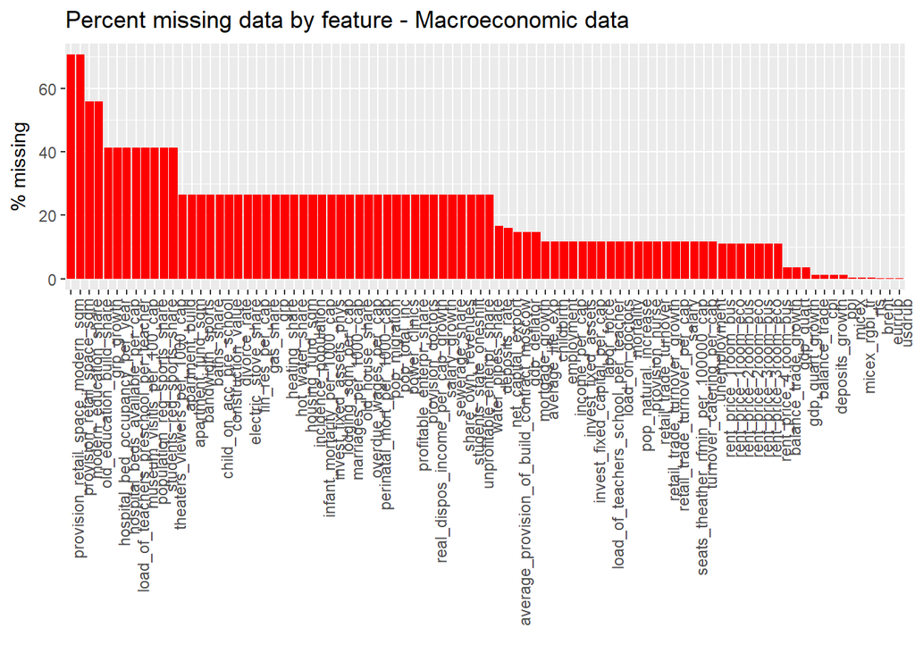

```r
#Missing values in macroeconomic data
miss_pct <- map_dbl(macro, function(x) { round((sum(is.na(x)) / length(x)) * 100, 1) })

miss_pct <- miss_pct[miss_pct > 0]

data.frame(miss=miss_pct, var=names(miss_pct), row.names=NULL) %>%
    ggplot(aes(x=reorder(var, -miss), y=miss)) +
    geom_bar(stat='identity', fill='red') +
    labs(x='', y='% missing', title='Percent missing data by feature - Macroeconomic data') +
    theme(axis.text.x=element_text(angle=90, hjust=1))
```

Summary of missing values by column:

```r
colSums(sapply(comb, is.na))
```

[output not shown]

[output cut: 731 more lines]

```
##                                      16901
##                           bandwidth_sports
##                                          0
##                population_reg_sports_share
##                                       3239
##                  students_reg_sports_share
##                                      16901
##                            apartment_build
##                                       3239
##                         apartment_fund_sqm
##                                          0
##                                       year
##                                          0
##                                      month
##                                          0
```

# Data Cleaning

The state feature is related to the apartment condition. Valid values are 1-4 with 1 being the worst condition and 4 being the best. The data contains what appears to be one erroneous outlier at 33:

```
##
##    1    2    3    4   33
## 4855 5844 5790  422    1
```

```r
comb <- subset(comb,state!=33) #remove outlier in apartment condition feature
```

Let’s take a look at the distribution of Sales Prices

```r
#Examine distribution of prices
salesdist <- ggplot(comb,aes(x=price_doc))+geom_histogram(col="blue",bins=500)+labs(x="Sales Price")
summary(comb$price_doc)
```

```
##     Min.  1st Qu.   Median     Mean  3rd Qu.     Max.
##   100000  5161000  6700000  7639000  8914000 95120000
```

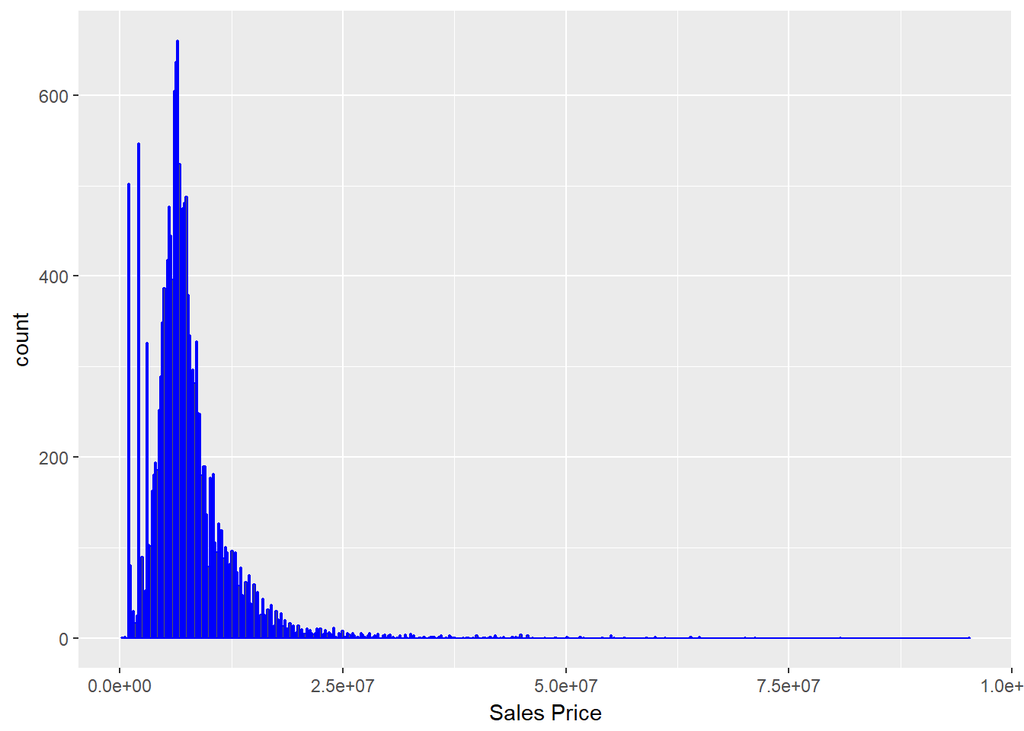

```r
salesdist
```

Sales prices are skewed with a long tail.

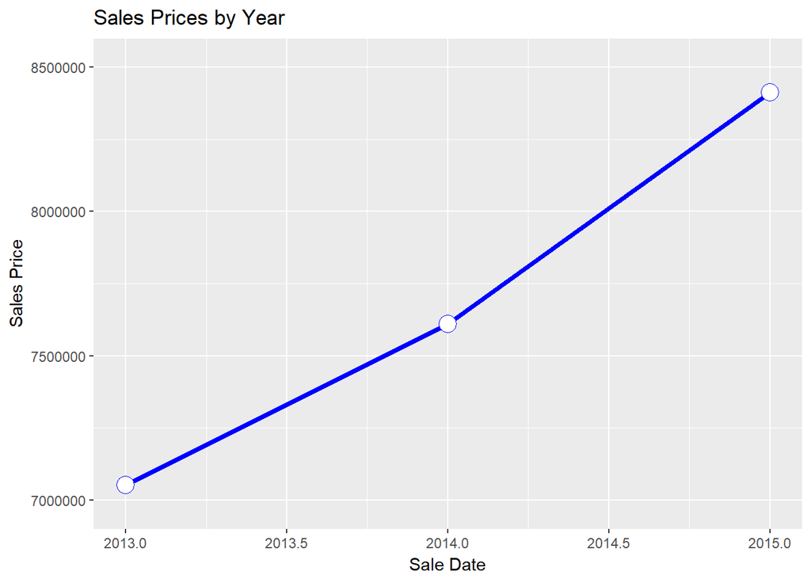

```r
#Plot Sales Price over time by year
ggplot(comb,aes(x=year,y=price_doc))+geom_line(stat="summary",color="blue",size=1.5)+geom_point(size=5,color="blue",fill="white",shape=21,stat="summary")+labs(x="Sale Date",y="Sales Price",title="Sales Prices by Year")
```

Sales prices were rising throughout the time period of the training dataset.

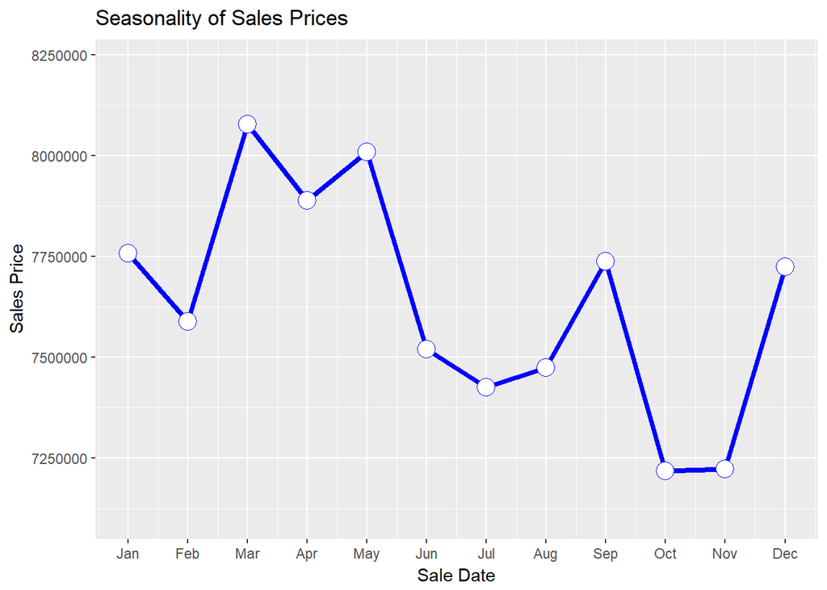

```r
#Plot sales prices by month to look for seasonal effects
ggplot(comb,aes(x=month,y=price_doc))+geom_line(stat="summary",color="blue",size=1.5)+geom_point(size=5,color="blue",fill="white",shape=21,stat="summary")+labs(x="Sale Date",y="Sales Price",title="Seasonality of Sales Prices")+scale_x_continuous(breaks=1:12,labels=c("Jan","Feb","Mar","Apr","May","Jun","Jul","Aug","Sep","Oct","Nov","Dec"))
```

It appears that there may be some seasonality present in realty prices, with highest prices early in the year, and weakness in mid Fall.